# Multiple regression

Takuya Shimamura

2021-06-30

**パッケージの読み込み**

```r
library(tidyverse)    # data manipulation
library(stargazer)    # summarize data
library(foreign)      # read '.dta' file (Stata ver.15~)
```

**データの読み込み**

```
#--- Stata ver. ---#

** recode log
log using lec_multiple_regression.log, replace

** do not pause for -more- message
set more off

** set current directory
cd "Z:XXXXXX"

** read data
use "labor2016_subsample_v11.dta", clear
```

```r
#--- R ver. ---#
df <- read.dta("./00_Input/labor2016_subsample_v11.dta")
df %>% as.tibble()  ## `tibble` is better to look than `data.frame`
```

```
## # A tibble: 6,057 x 8
##    female hours_meeting agg_industry  agg_occupation dprt_size domestic
##     <int> <fct>         <fct>         <fct>          <fct>     <fct>
##  1      1 1~5           manufacturing administrative 2-4       domestic
##  2      0 1~5           manufacturing administrative 50~99     domestic
##  3      0 1~5           transport     administrative 5-9       domestic
##  4      0 1~5           IT/Telcom     professional   10~19     domestic
##  5      0 0             IT/Telcom     professional   20~29     domestic
##  6      0 1~5           construction  supervisory    5-9       domestic
##  7      1 0             construction  administrative 2-4       domestic
##  8      0 1~5           manufacturing supervisory    2-4       domestic
##  9      0 5~10          construction  professional   5-9       domestic
## 10      0 1~5           construction  professional   5-9       domestic
## # ... with 6,047 more rows, and 2 more variables: othrs_busy <int>,
## #   job_rank <fct>
```

**データの確認**

```
#--- Stata ver. ---#

** check dataframe
describe

** show the first n rows
list in 1/7

** summarize data
summarize
```

```r
#--- R ver. ---#

## check dataframe
str(df)

## show the first n rows
head(df, n = 7)

## summarize data
summary(df)
```

## 0. 実証分析

### 0.1. 実証分析とは

#### **目標**

実証分析の目標は、経済理論と統計手法を応用し、 以下の3つを行うことである：

1. 理論予測の検証
2. 変数間にある因果関係の特定
3. 因果効果の推定

#### **相関関係の4つの解釈**

相関関係には、以下の4つの解釈が存在する：

1. 因果関係 (causality)
2. 逆因果関係 (reverse causality)
3. 第3因子 (third factor)
4. 単なる偶然 (coincidence)

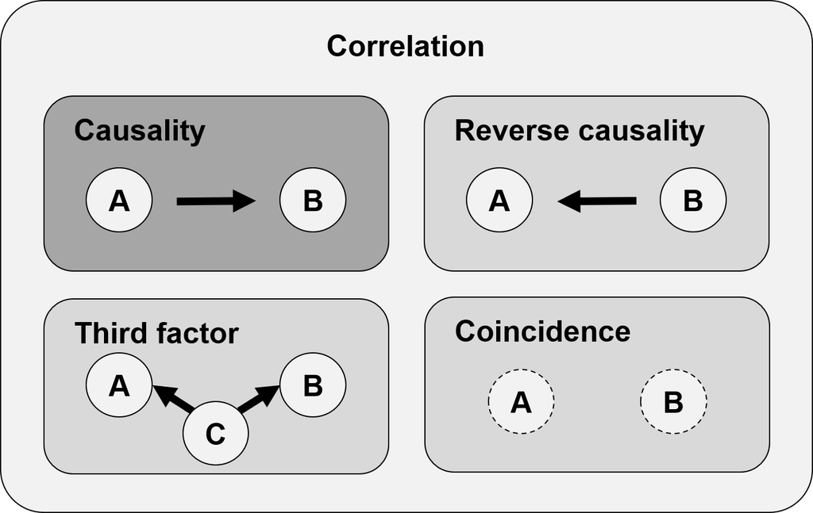

### 0.2. データの種類

社会科学のデータには、**実験データ**と**非実験データ(観察データ)**の2種類がある。

1. **実験データ**
- 処置や政策の評価・因果効果のためにデザインされた実験から得られるデータ (非常に理想的)
- 処置以外の他のすべての要因が (平均的に) 等しいグループをつくる ($E[ \epsilon |X] = 0$)  
  例）ランダム化比較試験 (RCT: randomized controlled trial)
2. **非実験データ**
- 人間の実際の行動や社会経済を対象としたデータ (ほとんどこっち)
- 処置の有無が処置以外の要因と関連 ($E[ \epsilon |X] \neq 0$)  
  例）国勢調査, GDP

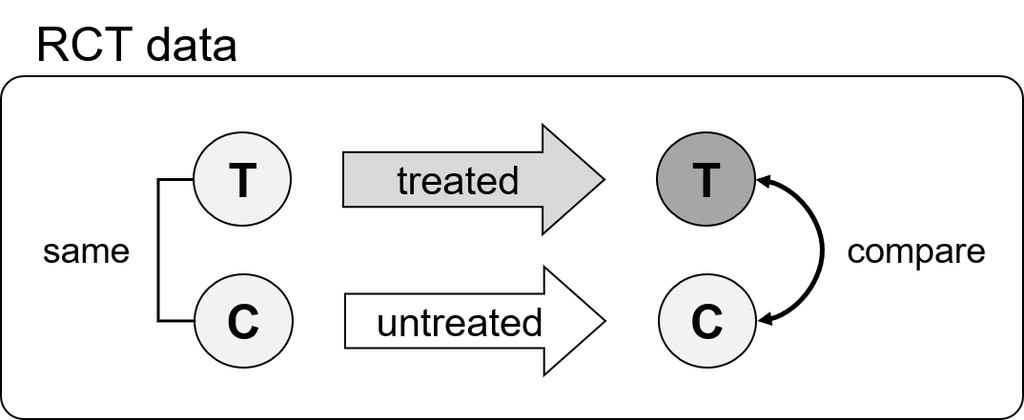

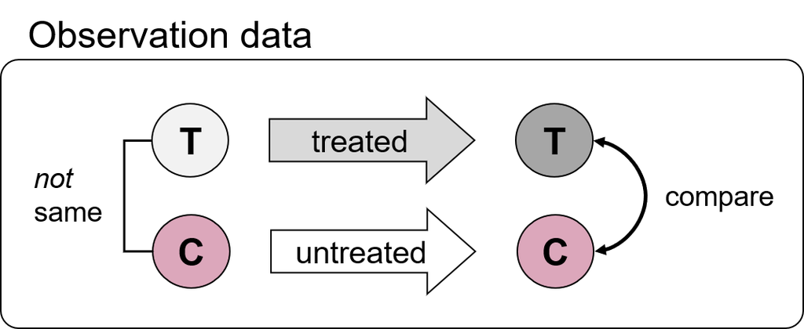

### 0.3. 回帰分析

#### **単回帰分析**

母集団の確率変数$Y$と$X$の間に、以下のような線形モデルを仮定した統計分析：

$$Y_i = \alpha + \beta X_i + \epsilon_i$$

- $i$: 観測主体 (individual ID)
- $Y_i$: 被説明変数 (explained variable)
- $X_i$: 説明変数 (explanatory variable)
- $\epsilon_i$: 誤差項 (error terms) ; $E[ \epsilon |X] = 0$

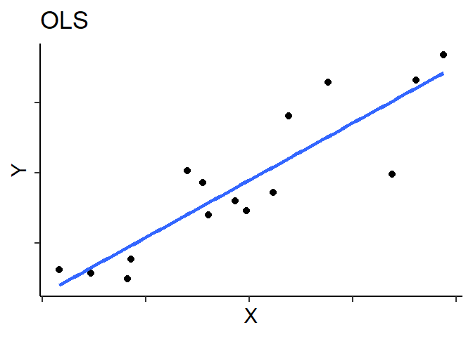

#### **重回帰分析**

複数の説明変数を含む回帰分析：

$$Y_i = \beta_0 + \beta_1 X_{1i} + \beta_2 X_{2i} + ... + \beta_K X_{Ki} + \epsilon_i \\
= \beta_0 + \pmb{X^{'}} \pmb{\beta} + \epsilon_i \hspace{86pt}$$
$$\begin{align}
Y_i &= \beta_0 + \beta_1 X_{1i} + \beta_2 X_{2i} + ... + \beta_K X_{Ki} + \epsilon_i \\
&= \beta_0 + \pmb{X^{'}} \pmb{\beta} + \epsilon_i
\end{align}$$

cf.
$$\pmb{X^{'}} \pmb{\beta} =
(X_1, X_2, \ldots, X_K)
\left (
\begin {array} {ccc}
\beta_1 \\
\beta_2 \\
\vdots \\
\beta_K \\
\end {array}
\right
)$$

## 1. 重回帰分析

### 1.1. 重回帰分析のパラダイム

重回帰分析には、新旧のパラダイムが存在する。

- 旧いパラダイム：  
  被説明変数$Y$が、複数の説明変数($X_1, X_2, ..., X_K$)によって、どのように決定されるかを分析する。
  - 探索的分析 (どの変数$X_k$が重要な決定要因になるか?)
  - 分析上、すべての変数は同じように重要である。  
    -> 被説明変数$Y$に影響を与えると考えられる変数はすべて入れる
- 新しいパラダイム：  
  被説明変数$Y$に対する、主変数$X$の **因果効果 (causal effect)** の不偏推定量を得るために、他の説明変数$Z$を制御する。

  $$Y_i = \alpha + \beta X_i + \gamma Z_i + \epsilon_i$$
  - 主変数$X_i$とコントロール変数$Z_i$の明示的な区別
  - $X_i$: 主変数
    - 主変数$X_i$の因果効果の分析：$\tfrac {\partial E[Y|X, Z]} {\partial X} = \beta$
  - $Z_i$: 制御変数 (control variable)
    - 加えるべき変数の条件は以下の2つ：
    1. その変数が、既に含まれている説明変数と相関する
    2. その変数が、被説明変数の決定要因である  
       -> 被説明変数$Y$に影響を与えると考えられる変数すべてを入れるのは間違い！

### 1.2. 単回帰分析の限界 [演習]

モチベーション：`othrs_busy`(残業時間) が長い原因を追究する！

```r
df <- read.dta("./00_Input/labor2016_subsample_v11.dta")
df %>% as.tibble()
```

```
## # A tibble: 6,057 x 8
##    female hours_meeting agg_industry  agg_occupation dprt_size domestic
##     <int> <fct>         <fct>         <fct>          <fct>     <fct>
##  1      1 1~5           manufacturing administrative 2-4       domestic
##  2      0 1~5           manufacturing administrative 50~99     domestic
##  3      0 1~5           transport     administrative 5-9       domestic
##  4      0 1~5           IT/Telcom     professional   10~19     domestic
##  5      0 0             IT/Telcom     professional   20~29     domestic
##  6      0 1~5           construction  supervisory    5-9       domestic
##  7      1 0             construction  administrative 2-4       domestic
##  8      0 1~5           manufacturing supervisory    2-4       domestic
##  9      0 5~10          construction  professional   5-9       domestic
## 10      0 1~5           construction  professional   5-9       domestic
## # ... with 6,047 more rows, and 2 more variables: othrs_busy <int>,
## #   job_rank <fct>
```

`hours_meeting`と`dprt_size`を少し編集。(今後の回帰分析の結果を見やすくするためなので必ずしも必要ではない)

```r
df <- df %>%
  mutate(
    hours_meeting = case_when(
      hours_meeting == "0" ~ "0",
      hours_meeting == "1~5" ~ "01-05",
      hours_meeting == "5~10" ~ "05-10",
      hours_meeting == "10~20" ~ "10-20",
      hours_meeting == "20~40" ~ "20-40",
      hours_meeting == "40~" ~ "40-"
    ),
    dprt_size = case_when(
      dprt_size == "1" ~ "001",
      dprt_size == "2-4" ~ "002-004",
      dprt_size == "5-9" ~ "005-009",
      dprt_size == "10~19" ~ "010-019",
      dprt_size == "20~29" ~ "010-019",
      dprt_size == "30~49" ~ "030-049",
      dprt_size == "50~99" ~ "050-099",
      dprt_size == "100~" ~ "100-"
    )
  )
```

まず、`othrs_busy`(残業時間) と `hours_meeting`(会議時間) の関係に注目する。  
つまり、会議時間 -> 残業時間 の因果関係を考察する。

#### **グラフ**

`othrs_busy`(残業時間) のヒストグラム

```
#--- Stata ver. ---#
histogram othrs_busy
```

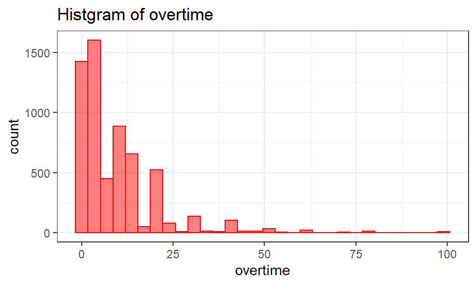

```r
#--- R ver. ---#
ggplot(data = df, aes(x = othrs_busy)) +  ## identify data and variables
  geom_histogram(col = "red", fill = "red", alpha = 0.5) +  ## identify density or frequency (default is freq.)
  ggtitle("Histgram of overtime") +  ## title of the plot
  xlab("overtime") + ylab("count") +  ## title of the axis
  theme_bw()  ## select theme
```

`hours_meeting`(会議時間) のヒストグラム

```
#--- Stata ver. ---#
histogram hours_meeting
```

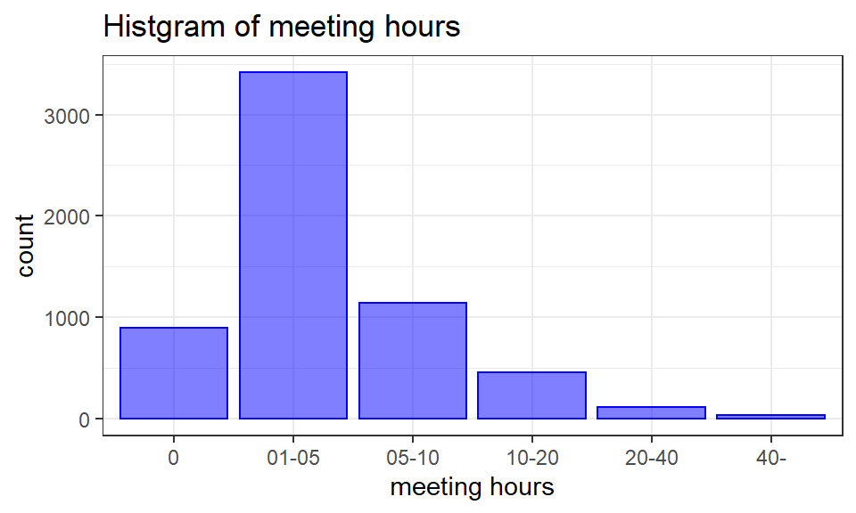

```r
#--- R ver. ---#
ggplot(data = df, aes(x = hours_meeting)) +  ## identify data and variables
  geom_bar(col = "blue", fill = "blue", alpha = 0.5) +  ## identify density or frequency (default is freq.)
  ggtitle("Histgram of meeting hours") +  ## title of the plot
  xlab("meeting hours") + ylab("count") +  ## title of the axis
  theme_bw()  ## select theme
```

散布図

```
#--- Stata ver. ---#
bysort hours_meeting: egen othrs_busy_mean = mean(othrs_busy)
scatter othrs_busy_mean hours_meeting
```

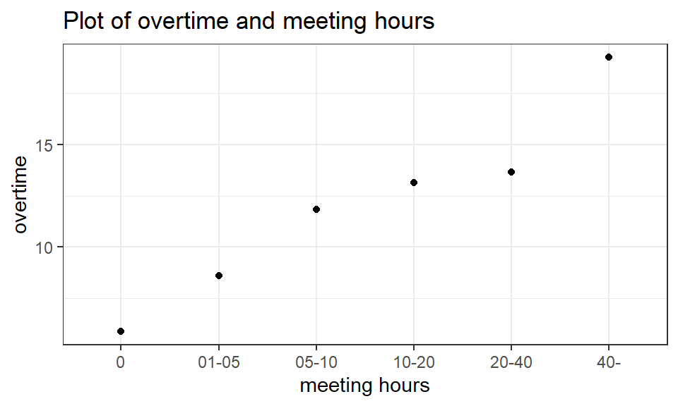

```r
#--- R ver. ---#
df %>%
  group_by(hours_meeting) %>%
  summarise_at("othrs_busy", mean, na.rm = TRUE) %>%
  #-- ggplot --#
  ggplot() +
  geom_point(aes(x = hours_meeting, y = othrs_busy)) +
  ggtitle("Plot of overtime and meeting hours") +
  xlab("meeting hours") + ylab("overtime") +
  theme_bw()
```

#### **回帰分析**

まず、`othrs_busy`(残業時間) と `hours_meeting`(会議時間) の因果関係を検証するために、以下のような単回帰分析を行う。

$$残業時間_i = \alpha + \beta 会議時間_i + \epsilon_i$$

ここで、`会議時間`は、カテゴリー変数であるため、ダミー変数に変換して、回帰分析をする必要がある。

| ID | $x_1$ | $x_2$ | $...$ | $x_n$ | $X$ |
| --- | --- | --- | --- | --- | --- |
| a | 0 | 1 | $...$ | 0 | 1 |
| b | 1 | 0 | $...$ | 0 | 1 |
| c | 0 | 0 | $...$ | 0 | 1 |
| d | 0 | 0 | $...$ | 1 | 1 |
| e | 1 | 0 | $...$ | 0 | 1 |
| $\vdots$ | $\vdots$ | $\vdots$ | $\ddots$ | $\vdots$ | $\vdots$ |

```
#--- Stata ver. ---#

** create dummy variables
gen meeting_0 = (hours_meeting == 0)
gen meeting_1 = (hours_meeting == 1)
gen meeting_2 = (hours_meeting == 2)
gen meeting_3 = (hours_meeting == 3)
gen meeting_4 = (hours_meeting == 4)
gen meeting_5 = (hours_meeting == 5)

** run OLS
reg othrs_busy meeting_1 meeting_2 meeting_3 meeting_4 meeting_5
*/ Note: We omitted the first dummy to avoid multicollinearity *
```

```r
#--- R ver. ---#

## create dummy variables
df_new <- df %>%
  mutate(
    meeting_0 = case_when(hours_meeting == '0' ~ 1, TRUE ~ 0),
    meeting_1 = case_when(hours_meeting == '01-05' ~ 1, TRUE ~ 0),
    meeting_2 = case_when(hours_meeting == '05-10' ~ 1, TRUE ~ 0),
    meeting_3 = case_when(hours_meeting == '10-20' ~ 1, TRUE ~ 0),
    meeting_4 = case_when(hours_meeting == '20-40' ~ 1, TRUE ~ 0),
    meeting_5 = case_when(hours_meeting == '40-' ~ 1, TRUE ~ 0)
  )

## run OLS
reg <- lm(othrs_busy ~ meeting_1 + meeting_2 + meeting_3 + meeting_4 + meeting_5, data = df_new)
summary(reg)
```

```
##
## Call:
## lm(formula = othrs_busy ~ meeting_1 + meeting_2 + meeting_3 +
##     meeting_4 + meeting_5, data = df_new)
##
## Residuals:
##     Min      1Q  Median      3Q     Max
## -19.257  -6.588  -3.588   3.179  90.412
##
## Coefficients:
##             Estimate Std. Error t value Pr(>|t|)
## (Intercept)   5.8863     0.3723  15.810  < 2e-16 ***
## meeting_1     2.7015     0.4184   6.458 1.15e-10 ***
## meeting_2     5.9347     0.4972  11.936  < 2e-16 ***
## meeting_3     7.2528     0.6427  11.284  < 2e-16 ***
## meeting_4     7.7624     1.1220   6.919 5.03e-12 ***
## meeting_5    13.3709     1.9212   6.959 3.78e-12 ***
## ---
## Signif. codes:  0 '***' 0.001 '**' 0.01 '*' 0.05 '.' 0.1 ' ' 1
##
## Residual standard error: 11.15 on 6051 degrees of freedom
## Multiple R-squared:  0.04044,    Adjusted R-squared:  0.03965
## F-statistic:    51 on 5 and 6051 DF,  p-value: < 2.2e-16
```

There is shortcut code above.

```
#--- Stata ver. ---#
reg othrs_busy i.hours_meeting
```

```r
#--- R ver. ---#
reg_single <- lm(othrs_busy ~ factor(hours_meeting), data = df)
summary(reg_single)
```

(**実験データ**であれば) 係数$\beta$から因果効果が推定できる。  
しかし、(**非実験データ**では) 相関関係は、必ずしも因果関係と一致しない！  
例えば、

- 逆因果関係：残業時間 $\uparrow$ $\: \Rightarrow \:$ 仕事疲れ $\uparrow$ $\: \Rightarrow \:$ 会議時間 $\uparrow$
- 第三因子 (交絡因子)：
  - 残業時間は`仕事量`に依存する。`会議時間`はあくまで`仕事量`を決定する一要因に過ぎない。
  - `会議時間`は他にも、`企業や部署の規模`, `業種`, `職種` などの要因に依存する。  
    因果推定のためには、「同じ企業・同じ業種・同じ職種・同じ性別・同じ年齢で、会議時間のみ変化させた場合に、残業時間の平均がどう変化するか」を考慮する必要がある。  
    つまり、`会議時間`とその他の`変数Z`を条件とする`残業時間`の条件付き確率を考える。

$$E[残業時間_i|会議時間_i, Z_i]$$

先ほどの単回帰分析に、制御のための変数$Z$を加える：

$$残業時間_i = \alpha + \beta 会議時間_i + \gamma Z_i + \epsilon_i$$

ここで、効果測定以外の条件を制御する目的で入れる変数$Z$を、**制御変数 (control variable)** または **共変量 (covariates)** という。

### 1.3. 欠落変数バイアス (omitted variable bias)

**欠落変数バイアス (omitted variable bias)** とは、 ある変数$X$の因果効果を見たいときに、

1. 説明変数$X$と相関し、
2. 被説明変数$Y$の決定要因である

ようなコントロール変数$Z$をモデルに加えないことによって推定された因果効果に生じるバイアスのこと。

#### **欠落変数バイアスの数学的証明**

- `真のモデル`： $Y_i = \alpha + \beta X_i + \gamma Z_i + \epsilon_i$
- `実際の推定モデル`： $Y_i = \alpha + \beta X_i + \epsilon_i$

最小二乗法(OLS)で推定すると、推定値は次の最適化問題の解に等しい：

$$\min_{a,b} \sum_{i=i}^{n} (Y_i - a - bX_i) ^2$$

1階条件は、

$$a: \sum_{i=1}^{n} (Y_i - a - bX_i) = 0$$
$$b: \sum_{i=1}^{n} X_i(Y_i - a - bX_i) = 0$$

- $a$について解くと、

$$a = \tfrac{1}{n} \sum_{i=1}^{n} (Y_i - b X_i) = \bar{Y} - b \bar{X}$$

- $b$について解くと、

$$\begin{align}
& \sum_{i=1}^{n} X_i (Y_i - \bar{Y} + b \bar{X} - bX_i) = 0 \hspace{73pt} (aを代入)\\
& \sum_{i=1}^{n} (X_i - \bar{X}) (Y_i - \bar{Y}) = b \sum_{i=1}^{n} (X_i - \bar{X}) ^2 \hspace{40pt} (bに関してまとめる) \\\\
& b = \frac {\sum_{i=1}^{n} (X_i - \bar{X}) (Y_i - \bar{Y})} {\sum_{i=1}^{n} (X_i - \bar{X}) ^2} = \frac {Cov(X, Y)} {Var(X)} \hspace{28pt} (OLSの公式) \\
\end{align}$$

ここで、上記のOLSの公式の$Y$に、`真のモデル`を代入すると、

$$\begin{align}
b &= \frac {\sum_{i=1}^{n} (X_i - \bar{X_i}) (\alpha + \beta X_i + \gamma Z_i + \epsilon_i - (\alpha + \beta \bar{X_i} + \gamma \bar{Z_i} + \bar{\epsilon_i})) } {\sum_{i=1}^{n} (X_i - \bar{X_i}) ^2} \\\\
&= \frac {\sum_{i=1}^{n} (X_i - \bar{X_i}) [\beta (X_i - \bar{X_i}) + \gamma (Z_i - \bar{Z_i}) + (\epsilon_i - \bar{\epsilon_i})]} {\sum_{i=1}^{n} (X_i - \bar{X_i}) ^2} \\\\
&= \frac {\sum_{i=1}^{n} \beta (X_i - \bar{X_i}) ^2 + \gamma (X_i - \bar{X_i})(Z_i - \bar{Z_i}) + (X_i - \bar{X_i})(\epsilon_i - \bar{\epsilon_i})} {\sum_{i=1}^{n} (X_i - \bar{X_i}) ^2} \\\\
&= \beta + \gamma \frac {\sum_{i=1}^{n} (X_i - \bar{X_i})(Z_i - \bar{Z_i})} {(X_i - \bar{X_i}) ^2} + \frac {\sum_{i=1}^{n} (X_i - \bar{X}) (\epsilon_i - \bar{\epsilon_i})} {\sum_{i=1}^{n} (X_i - \bar{X}) ^2} \hspace{30pt} (E[\epsilon |X] = 0 より) \\\\
&= \beta + \gamma \frac {\sum_{i=1}^{n} (X_i - \bar{X_i})(Z_i - \bar{Z_i})} {(X_i - \bar{X_i}) ^2} \\\\
\end{align}$$

以上より、欠落変数バイアスは、

$$\begin{align}
E[\beta |X, Z] &= \beta + \gamma \frac {\sum_{i=1}^{n} (X_i - \bar{X_i})(Z_i - \bar{Z_i})} {(X_i - \bar{X_i}) ^2} \\
&= \beta + \gamma \beta_{XZ}
\end{align}$$

と表すことができる。

#### **欠落変数バイアスの解釈**

1. 欠落変数バイアスの有無  
   OLSがバイアスを持つのは、以下の2つの条件がそろうときである：
   1. $\gamma \neq 0$ $←$ $Z$は被説明変数$Y$と関係している
   2. $\beta_{XZ} \neq 0$ $←$ $X$と$Z$が相関している
2. 欠落変数バイアスの方向性  
   $\gamma$と$\beta_{XZ}$の正負からバイアスの方向性が分かる。
   - 例）$\gamma > 0$ かつ $\beta_{XZ} > 0$ のとき、$\gamma \beta_{XZ} > 0$

     $Z$を`職位`とすると、
     - `職位` $\uparrow$ $\: \Rightarrow \:$ `残業時間` $\uparrow$ ： $\gamma > 0$
     - `職位` $\uparrow$ $\: \Rightarrow \:$ `会議時間` $\uparrow$ ： $\beta_{XZ} > 0$  
       $\therefore$ 職位の高低が、正のバイアスを生む。
3. RCT実験にコントロール変数$Z$が要らない理由  
   RCT実験では、$X$の効果を ($Z$に関係なく) ランダムに割り当てる。  
   つまり、$\beta_{XZ} = 0$ となり、欠落変数バイアスが生じない。

### 1.4. 欠落変数 [演習]

欠落変数バイアスに対処するためは、主変数(`会議時間`)と相関している変数を見つける必要がある。  
ここでは、`性別`と`役職`について、`会議時間`との相関 ($Cov(X, Z \neq 0)$) を確認する。  
なお、後述する通り、`性別`と`役職`は、被説明変数(`残業時間`)の前に確定されている変数(pre-determined)であり、良いコントロール変数であると考えられる。  
確認の方法には、便宜的にグラフによる可視化を採用する。

#### (a) **会議時間と性別**

```
#--- Stata ver. ---#
bysort hours_meeting: egen female_mean = mean(female)
scatter female_mean hours_meeting
tab hours_meeting female
```

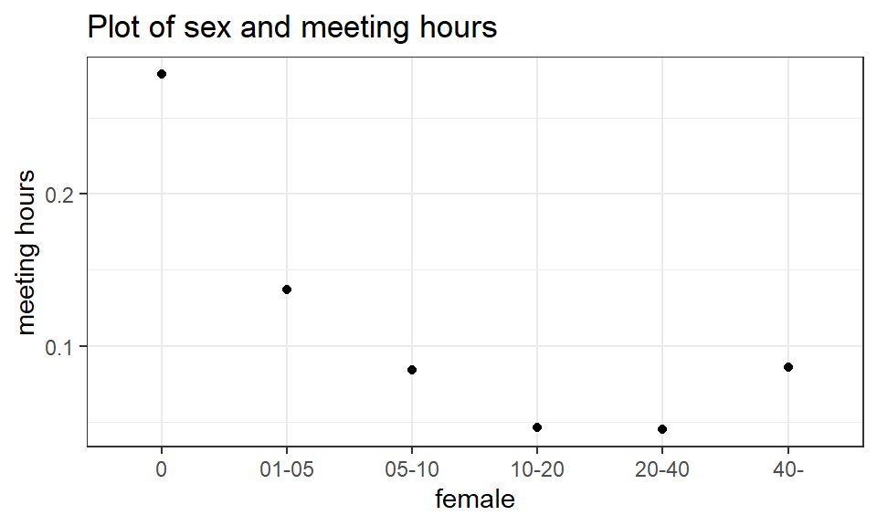

```r
#--- R ver ---#
df %>% group_by(hours_meeting) %>%
  summarise_at("female", mean, na.rm = TRUE) %>%
  #-- ggplot --#
  ggplot() +
  geom_point(aes(x = hours_meeting, y = female)) +
  ggtitle("Plot of sex and meeting hours") +
  xlab("female") + ylab("meeting hours") +
  theme_bw()
```

グラフから分かるように、`会議時間`と`性別`の間には、相関が見られる。

#### (b) **会議時間と職位**

```
#--- Stata ver. ---#
bysort hours_meeting: egen rank_mean = mean(job_rank)
scatter rank_mean hours_meeting
tab hours_meeting job_rank
```

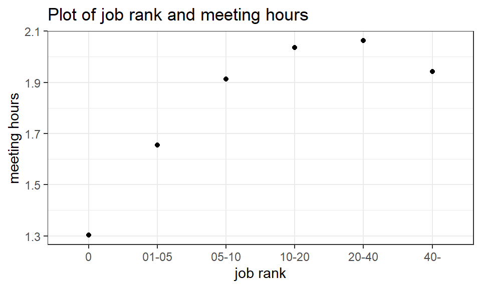

```r
#--- R ver. ---#
df %>%
  mutate(job_rank_factor = job_rank %>% factor() %>% as.integer()) %>%
  group_by(hours_meeting) %>%
  summarise_at("job_rank_factor", mean, na.rm = TRUE) %>%
  #-- ggplot --#
  ggplot() +
  geom_point(aes(x = hours_meeting, y = job_rank_factor)) +
  ggtitle("Plot of job rank and meeting hours") +
  xlab("job rank") + ylab("meeting hours") +
  theme_bw()
```

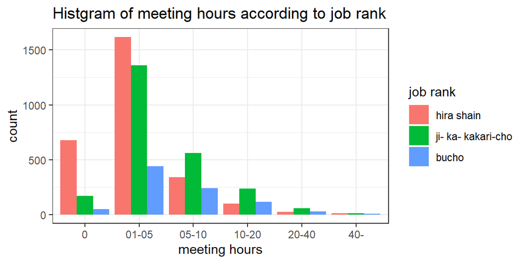

```r
df %>%
  group_by(hours_meeting, job_rank) %>%
  summarise(n = n()) %>%
  #-- ggplot --#
  ggplot(aes(x = hours_meeting, y = n, fill = job_rank)) +
  geom_bar(stat = "identity", position = "dodge")+
  ggtitle("Histgram of meeting hours according to job rank") +
  xlab("meeting hours") + ylab("count") + labs(fill = "job rank") +
  theme_bw()
```

グラフから分かるように、`会議時間`と`職位`の間には、相関が見られる。

(a)(b)より、`性別`と`役職`は、主変数`会議時間`と被説明変数`残業時間`の回帰分析のコントロール変数として相応しい。  
または、この回帰モデルに、`性別`と`役職`を加えないと、**欠落変数バイアス**が、生じる可能性が高い。

### 1.5. コントロール変数の良し悪し

良いコントロール変数を選択するためには、少なくとも以下の2点に気をつける必要がある。

1. 誤差項の期待値ゼロ
2. 必要最小限の変数

#### (i) **誤差項の期待値ゼロ**

「良いコントロール変数」は、その変数を制御した際に、誤差項の期待値がゼロになるような変数である：

$$E[\epsilon_i | X_i, Z_i] = 0$$

さもなければ、別の欠落変数バイアスが生じるのと同じ結果となってしまう：

$$Y_i = \alpha + \beta X_i + \gamma Z_i + U_i + \epsilon_i$$

(例外もあるが) 一般に、

- 良いコントロール変数：被説明変数$Y$の前に確定されている変数 (pre-determined)  
  例）業種, 職種, 性別, 年齢
- 悪いコントロール変数：被説明変数$Y$と同時または後に確定された変数  
  例）雑務の多さ, 職場の雰囲気, 労働賃金率

と言える。 ただし、$Y$と$Z$に serial correlation がある場合は、その限りではない。

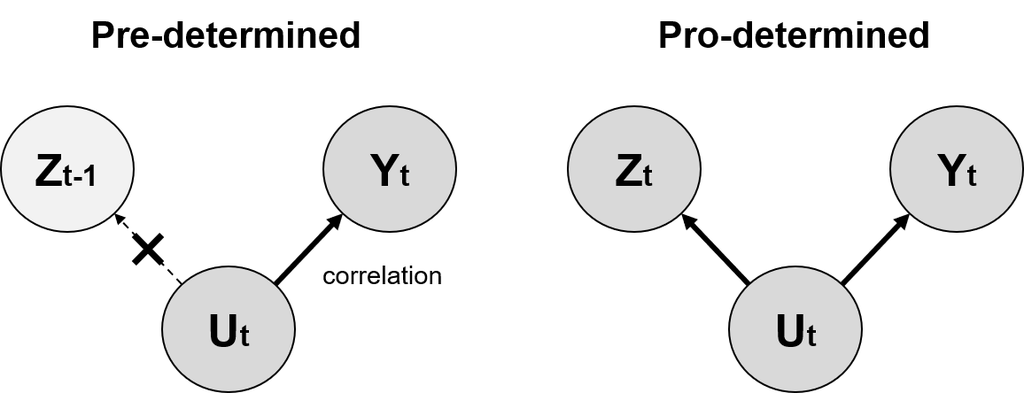

#### (ii) **必要最小限の変数**

コントロール変数は必要最小限にとどめることが望ましく、むやみに変数の数を増やすべきではない。

1. 欠落変数バイアスの公式：

$$E[\beta |X, Z] = \beta + \gamma \frac {\sum_{i=1}^{n} (X_i - \bar{X_i})(Z_i - \bar{Z_i})} {(X_i - \bar{X_i}) ^2} \\$$

よって、$X$との相関の高いコントロール変数ほど、制御する必要がある。

2. 一方、OLS推定値の分散の公式：

$$Var[\beta |X, Z] = \frac {\sigma ^2} {\sum_{i=1}^{n} (X_i - \bar{X_i})^2 (1 - R_{XZ}^{2})}$$

よって、$X$と$Z$の決定係数$R_{XZ}^2$が高いほど、分散が大きくなる ($\simeq$ 推定された係数$\beta$の信頼性が減少する)  
これを、**多重共線性 (multicollinearity) 問題** と呼ぶ。  
また、一般に、重回帰モデルの決定係数$R^2$は、変数の数を増やせば増やすほど、(各変数の重要度に限らず) 増加する。

### 1.6. 内生性 (endogeneity)

$E[\epsilon_i | X_i] = 0$：誤差項が説明変数$X_i$と平均的に独立している (ガウス=マルコフの仮定の1つ) が成立しないことを、  
説明変数の **内生性の問題 (endogeneity problem)** という。

内生性 ($Cov(X, \epsilon) \neq 0$) には以下の4つの原因がある：

1. 欠落変数 (ommitted variables)
   1. 観測可能な変数 (observables)
   2. 観測不可能な変数 (unobservables)
2. (説明変数の)観測誤差 (measurement error)
3. 同時性/逆因果 (simultaneity / reverse causality)
4. サンプルセレクション (sample selection)

以下、

- i-a 観測不可能な欠落変数
- ii 観測誤差

を検討する。

#### **観測不可能な欠落変数 (unobservable)**

先ほどの重回帰モデルを再考する：

$$残業時間_i = \alpha + \beta 会議時間_i + \gamma Z_i + \epsilon_i$$

$Z$の中次のような (観測可能な) コントロール変数を含める：

- 企業属性 (業種, 企業規模, 日系or外資系)
- 仕事属性 (職種, 職位, 部下の人数)
- 個人属性 (性別, 年齢, 婚約, 教育水準)

しかし、OLS推定量はおそらく不偏とは言えない。 なぜならば、

- 企業の効率性
- 上司の効率性

など、観測不可能な要因が、$X$(`会議時間`)と$Y$(`残業時間`)の両方に影響を及ぼしている可能性が高い。  
つまり、(観測可能な)$Z$を制御した上でも、主変数$X$と誤差項$\epsilon$の相関はゼロにならない：

$$Cov(X, \epsilon | Z) \neq 0$$

#### **代理変数 (proxy variable)**

観測不可能な要因$u^*$を制御するための手段として、**代理変数 (proxy variable)** を用いる：

$$残業時間_i = \alpha + \beta 会議時間_i + \gamma Z_i + u_i^* + \epsilon_i$$

例えば、「自費立替が企業から払い戻されるまでの時間」$u_i$を、「企業の非効率性」の代理変数として用いる。  
良い代理変数は、以下の2つの条件がよく知られている (後述のように、ほとんど満たされない)：

1. 線形近似が可能 $u_i^* = \delta_0 + \delta_1 u_1 + e_i$
2. 近似誤差$e_i$と相関ゼロ $E[e_i | u_i] = 0$  
   ($u_i^*$: 観測不可能な要因，$u_i$: 代理変数)

上記の2つの条件下では、OLS推定が不偏となる：

$$\begin{align}
残業時間_i &= \alpha + \beta 会議時間_i + \gamma Z_i + u^* + \epsilon_i \\
&= \alpha + \beta 会議時間_i + \gamma Z_i + \delta_0 + \delta_1 u_i + e_i + \epsilon_i \\
&= (\alpha + \delta_0) + \beta 会議時間_i + \gamma Z_i + \delta_1 u_i + (e_i + \epsilon_i) \\
&= \alpha_0 + \beta 会議時間_i + \gamma Z_i + \delta_1 u_i + \nu_i
\end{align}$$

$\therefore$ 新しく定義された誤差項$\nu_i$は、$u_i$を制御した後では、他の変数との相関はゼロとなる。

$$\begin{align}
& E[e_i + \epsilon_i | X_i, Z_i, u_i] = 0 \\
& E[\nu_i | X_i, Z_i, u_i] = 0 \\
\end{align}$$

#### **観測誤差 (measurement error)**

良い代理変数の2つ目の条件($E[e_i | u_i] = 0$)を考える

- $E[e_i | u_i] = 0 \Leftrightarrow Cov(e, u) = 0$
- 最高に良い代理変数$u_i$という仮定：$u_i^* = u_i + e_i$  
  より、

$$\begin{align}
Cov(e_i, u_i) &= Cov(e_i, u_i^* + e_i) \\
&= Cov(e_i, u_i^*) - Var(e_i) \\
\end{align}$$

ここで、

$$Cov(e_i, u_i) = 0 \: \Longrightarrow \: Cov(e_i, u_i^*) = Var(e_i)$$

$\therefore$ 良い代理変数とは、`代理変数の誤差項と観測不可能な変数の共分散`と`代理変数の誤差項の分散`が偶然一致するような変数である。  
現実的には、このような偶然は起こらず、代理変数の誤差項と代理変数の相関はゼロとはならない ($Cov(e, u) \neq 0$)。 これを、**測定誤差問題 (measurement error problem)** という。

### 1.7. 重回帰分析 [演習]

`会議時間`を主変数とする回帰モデルに、以下のコントロール変数：

- 性別
- 産業
- 職種
- 職位
- 部署規模
- 日系or外資系

を加えて、`残業時間`を説明する。

```
#--- Stata ver. ---#
reg oth i.hours_meeting i.agg_industry i.agg_occupation /*
*/ i.job_rank i.dprt_size domestic female
```

```r
#--- R ver. ---#
reg_multi <- lm(othrs_busy ~ factor(hours_meeting) + female + factor(job_rank) +
                  factor(agg_industry) +  factor(agg_occupation) +
                  factor(dprt_size) + factor(domestic),
                data = df)
summary(reg_multi)
```

```
##
## Call:
## lm(formula = othrs_busy ~ factor(hours_meeting) + female + factor(job_rank) +
##     factor(agg_industry) + factor(agg_occupation) + factor(dprt_size) +
##     factor(domestic), data = df)
##
## Residuals:
##     Min      1Q  Median      3Q     Max
## -24.314  -6.788  -2.980   3.456  90.993
##
## Coefficients:
##                                       Estimate Std. Error t value Pr(>|t|)
## (Intercept)                             6.2254     1.2990   4.792 1.69e-06 ***
## factor(hours_meeting)01-05              2.1583     0.4585   4.708 2.56e-06 ***
## factor(hours_meeting)05-10              5.0813     0.5564   9.132  < 2e-16 ***
## factor(hours_meeting)10-20              6.3555     0.7032   9.038  < 2e-16 ***
## factor(hours_meeting)20-40              6.4349     1.1737   5.482 4.37e-08 ***
## factor(hours_meeting)40-               15.3857     2.0485   7.511 6.77e-14 ***
## female                                 -1.6422     0.4774  -3.440 0.000587 ***
## factor(job_rank)ji- ka- kakari-cho      1.4646     0.3533   4.145 3.45e-05 ***
## factor(job_rank)bucho                  -0.3894     0.5185  -0.751 0.452698
## factor(agg_industry)manufacturing      -1.9222     0.5213  -3.688 0.000229 ***
## factor(agg_industry)IT/Telcom          -1.7200     0.6106  -2.817 0.004867 **
## factor(agg_industry)transport          -0.3678     0.8329  -0.442 0.658830
## factor(agg_industry)wholesale/retail   -2.0353     0.6319  -3.221 0.001284 **
## factor(agg_industry)finance/insurance  -2.0096     0.7018  -2.864 0.004204 **
## factor(agg_occupation)professional      2.4443     0.4707   5.193 2.14e-07 ***
## factor(agg_occupation)administrative    0.6068     0.4916   1.234 0.217086
## factor(agg_occupation)sales             0.8986     0.5796   1.550 0.121086
## factor(agg_occupation)service           1.0354     1.4744   0.702 0.482549
## factor(dprt_size)002-004                1.1717     0.9595   1.221 0.222038
## factor(dprt_size)005-009                0.5235     0.9441   0.554 0.579302
## factor(dprt_size)010-019                1.6527     0.9433   1.752 0.079829 .
## factor(dprt_size)030-049                1.5681     1.0441   1.502 0.133197
## factor(dprt_size)050-099                2.3767     1.0636   2.235 0.025477 *
## factor(dprt_size)100-                   1.6532     1.0613   1.558 0.119373
## factor(domestic)domestic               -0.9367     0.6465  -1.449 0.147403
## ---
## Signif. codes:  0 '***' 0.001 '**' 0.01 '*' 0.05 '.' 0.1 ' ' 1
##
## Residual standard error: 11.09 on 5802 degrees of freedom
##   (230 observations deleted due to missingness)
## Multiple R-squared:  0.06306,    Adjusted R-squared:  0.05918
## F-statistic: 16.27 on 24 and 5802 DF,  p-value: < 2.2e-16
```

#### **単回帰分析と重回帰分析の比較**

単回帰分析と重回帰分析の結果の比較を行う。 (`stargazer`パッケージの詳しい使い方は、[Jakerussさんのcheatsheet](https://www.jakeruss.com/cheatsheets/stargazer/)がベスト)

```r
stargazer(
  reg_single, reg_multi, type = "text",
  title = "Compare single and multiple regression",
  dep.var.labels = "overtime",
  column.labels = c("single regression", "multi regression"),
  omit = c("female", "job_rank", "agg_industry", "agg_occupation", "dprt_size", "domestic"),
  add.lines = list(
    c("control (sex)", "No", "Yes"),
    c("control (job rank)", "No", "Yes"),
    c("control (industry)", "No", "Yes"),
    c("control (occupation)", "No", "Yes"),
    c("control (department size)", "No", "Yes"),
    c("control (demmestic)", "No", "Yes")
  )
)
```

```
##
## Compare single and multiple regression
## =============================================================================
##                                           Dependent variable:
##                            --------------------------------------------------
##                                                 overtime
##                               single regression         multi regression
##                                      (1)                       (2)
## -----------------------------------------------------------------------------
## factor(hours_meeting)01-05         2.702***                 2.158***
##                                    (0.418)                   (0.458)
##
## factor(hours_meeting)05-10         5.935***                 5.081***
##                                    (0.497)                   (0.556)
##
## factor(hours_meeting)10-20         7.253***                 6.355***
##                                    (0.643)                   (0.703)
##
## factor(hours_meeting)20-40         7.762***                 6.435***
##                                    (1.122)                   (1.174)
##
## factor(hours_meeting)40-          13.371***                 15.386***
##                                    (1.921)                   (2.049)
##
## Constant                           5.886***                 6.225***
##                                    (0.372)                   (1.299)
##
## -----------------------------------------------------------------------------
## control (sex)                         No                       Yes
## control (job rank)                    No                       Yes
## control (industry)                    No                       Yes
## control (occupation)                  No                       Yes
## control (department size)             No                       Yes
## control (demmestic)                   No                       Yes
## Observations                        6,057                     5,827
## R2                                  0.040                     0.063
## Adjusted R2                         0.040                     0.059
## Residual Std. Error           11.151 (df = 6051)       11.086 (df = 5802)
## F Statistic                51.002*** (df = 5; 6051) 16.270*** (df = 24; 5802)
## =============================================================================
## Note:                                             *p<0.1; **p<0.05; ***p<0.01
```

比較から以下の2つのことが分かる：

- 40時間以上の会議時間を除き、**バイアスの方向**は、`正`であった。 (cf. 欠落変数バイアスの解釈)
- すべての会議時間で、**標準偏差**が大きくなった。 (cf. 多重共線性問題)

### 1.8. 検定

#### **仮設検定**

係数$\beta$が統計的に有意か否かの検定

- 帰無仮説 H0：$\beta = 0$
- 帰無仮説 H1：$\beta \neq 0$
1. <中心極限定理> 標本サイズが十分に大きいとき、(誤差項が正規分布でなくても) OLS推定量は近似的に正規分布に従う：

$$b_k \sim N(\beta_k, Var(\beta_k)) \: \Longrightarrow \: \frac {b_k - \beta_k} {\sqrt{Var(\beta_k)}} \sim N(0, 1)$$

2. 誤差項の分布$\sigma^2$は既知ではないので、推定分散$s^2$を使って標準誤差$s.e.$を推定する：

$$s^2 = \frac {1} {n - (k+1)} \sum_{i=1}^n e_i \: \Longrightarrow \: se(b_k) \simeq \sqrt {\frac {s^2} {\sum_{i=1}^n} (X_i - \bar{X_i}^2 (1 - R_{XZ}^2))}$$

3. 標準誤差によって正規化された推定量(t統計推定量)は、自由度$n-(k+1)$のt分布に従う：

$$\frac {b_k - \beta_k} {se(b_k)} \: \sim \: t \: (n - (k + 1))$$

#### **複合仮設検定**

複数の係数が同時に有意か否かの検定

$$Y_i = \alpha + \beta X_i + \gamma Z_{1i} + \delta Z_{2i} + \epsilon_i$$

- 例1) 重回帰モデル自体が有意か否か (H0: $\beta = \gamma = \delta = 0$
- 例2) コントロール変数が適切か (H0: $\gamma = \delta = 0$)
- 例3) パラメータが理論上の制約に従うか ($\beta + \gamma + \delta = 1$)

このような複合仮設検定では、次の統計量(F検定統計量)がF分布に従う：

$$F = \frac {[SSR_r - SSR_u] / q} {SSR_u / [n - {k + 1}]} \: \sim \: F \: (q, n - (k + 1))$$

- $SSR_r$: 帰無仮説を仮定した制約ありの場合の回帰モデルの残差二乗和 (例2: $Y_i = \beta_0 + \epsilon_i$)
- $SSR_u$: 対立仮説を仮定した制約なしの場合の回帰モデルの残差二乗和 (例2: $Y_i = \alpha + \beta X_i + \gamma Z_{1i} + \delta Z_{2i} + \epsilon_i$)
- $q$: 対立仮説と帰無仮説のパラメータ数の差
  - $SSR_r - SSR_u$の自由度：$[n - (k+1-q)] - [n - (k+1)] = q$

#### **Chow検定**

ある推定式の関係性がグループ間で異なるか否の検定

- 帰無仮説 H0: $\alpha_k = \beta_k$ for all $k$
- 対立仮説 H1: $\alpha_k \neq \beta_k$ for some $k$
  - 帰無仮説 H0: $Y_i = \alpha_0 + \alpha_1 X_{1i} + \dots + \alpha_K X_{1K} + \epsilon_i$
  - 対立仮説 H1: $Y_i = \beta_0 + \beta_1 X_{1i} + \dots + \beta_K X_{1K} + \epsilon_i$

このようなChow検定では、次の統計量(F検定統計量)がF分布に従う：

$$F = \frac {[SSR - (SSR_1 + SSR_2)] / (K+1)} {(SSR_1 + SSR_2) / [n - 2(k + 1)]} \: \sim \: F \: (K+1, n - 2(k + 1))$$

- $SSR$: 帰無仮説を仮定した制約ありの場合の回帰モデルの残差二乗和 (グループ間をまとめて推定するモデル)
- $(SSR_1 + SSR_2)$: 対立仮説を仮定した制約なしの場合の回帰モデルの残差二乗和 (グループ間を別々に推定するモデル)
- $K$: パラメータの総数

```r
anova(reg_multi)
```

```
## Analysis of Variance Table
##
## Response: othrs_busy
##                          Df Sum Sq Mean Sq F value    Pr(>F)
## factor(hours_meeting)     5  30883  6176.5 50.2550 < 2.2e-16 ***
## female                    1   3688  3687.9 30.0067 4.487e-08 ***
## factor(job_rank)          2   3495  1747.5 14.2182 6.922e-07 ***
## factor(agg_industry)      5   2876   575.2  4.6798 0.0002883 ***
## factor(agg_occupation)    4   4963  1240.9 10.0962 3.839e-08 ***
## factor(dprt_size)         6   1830   304.9  2.4810 0.0212740 *
## factor(domestic)          1    258   258.0  2.0995 0.1474032
## Residuals              5802 713089   122.9
## ---
## Signif. codes:  0 '***' 0.001 '**' 0.01 '*' 0.05 '.' 0.1 ' ' 1
```